# Plotting RS data

O’Connell, JL

9/7/2021

## Introduction to plotting Remote sensing data

This is an R markdown document that allows you to weave text and code together. Let’s start by setting the path to our project directory.

```r
setwd("C:/Users/ddunn/OneDrive/Documents/R/523d/523Dintro")
```

At that path, we should have a directory that contains all project files to keep things organized. The project folder structure looks something like this:

Project folder:

data: folder for all raw data, never manipulated, always preserved

documents: folder for manuscripts, markdown documents and other text based documentation

analysis: folder for all R scripts/code files; we use these code files to change and process the raw data as needed too.

output: folder where all output from code gets saved. This is where processed data is found

results: figures and tables created by code can get saved here

**Never** scatter all your files around your computer. This is always bad practice, but especially bad practice for remote sensing data. Keep all files that belong to the same project in a common directory in a well organized structure.

## Plotting some data

Let’s create a plot of RS data, to get us warmed up. First load the data. Note that since we set our working directory, we can now use relative paths that assume we are in that directory.

```r
##load Hadley wickham's tidyverse library which has lots of helpful functions. See the R for data science book in your syllabus.
library(tidyverse)
```

```r
##load some data collected with a field hyperspectral radiometer
dat<-read_csv("data/seagrant_reflect_05032016.csv")
##examine the data
names(dat)
```

```
##  [1] "wave" "m1"   "m2"   "m3"   "m4"   "m5"   "m6"   "s1"   "s2"   "s3"
## [11] "s4"   "s5"   "s6"   "t1"   "t2"   "t3"   "t4"   "t5"   "t6"   "date"
```

```r
str(dat)
```

```
## spc_tbl_ [220 × 20] (S3: spec_tbl_df/tbl_df/tbl/data.frame)
##  $ wave: num [1:220] 330 340 350 360 370 380 390 400 410 420 ...
##  $ m1  : num [1:220] 1.41 1.35 1.32 1.32 1.32 ...
##  $ m2  : num [1:220] NA NA NA NA 2.3 ...
##  $ m3  : num [1:220] 2.63 2.59 2.54 2.53 2.56 ...
##  $ m4  : num [1:220] 3.07 3.02 3.04 3.12 3.26 ...
##  $ m5  : num [1:220] 2.36 2.32 2.29 2.3 2.34 ...
##  $ m6  : num [1:220] 2.55 2.5 2.48 2.52 2.59 ...
##  $ s1  : num [1:220] NA NA NA NA 1.66 ...
##  $ s2  : num [1:220] 2.84 2.81 2.8 2.84 2.92 ...
##  $ s3  : num [1:220] 1.44 1.4 1.39 1.41 1.45 ...
##  $ s4  : num [1:220] 2.61 2.57 2.56 2.58 2.64 ...
##  $ s5  : num [1:220] NA NA NA NA 2.51 ...
##  $ s6  : num [1:220] 2.48 2.44 2.41 2.41 2.45 ...
##  $ t1  : num [1:220] 2.24 2.15 2.08 2.06 2.09 ...
##  $ t2  : num [1:220] 2.01 1.96 1.88 1.87 1.88 ...
##  $ t3  : num [1:220] 2.19 2.13 2.08 2.09 2.12 ...
##  $ t4  : num [1:220] 1.23 1.22 1.21 1.23 1.27 ...
##  $ t5  : num [1:220] 2.45 2.43 2.44 2.5 2.59 ...
##  $ t6  : num [1:220] NA NA NA NA 1.24 ...
##  $ date: Date[1:220], format: "2016-05-03" "2016-05-03" ...
##  - attr(*, "spec")=
##   .. cols(
##   ..   wave = col_double(),
##   ..   m1 = col_double(),
##   ..   m2 = col_double(),
##   ..   m3 = col_double(),
##   ..   m4 = col_double(),
##   ..   m5 = col_double(),
##   ..   m6 = col_double(),
##   ..   s1 = col_double(),
##   ..   s2 = col_double(),
##   ..   s3 = col_double(),
##   ..   s4 = col_double(),
##   ..   s5 = col_double(),
##   ..   s6 = col_double(),
##   ..   t1 = col_double(),
##   ..   t2 = col_double(),
##   ..   t3 = col_double(),
##   ..   t4 = col_double(),
##   ..   t5 = col_double(),
##   ..   t6 = col_double(),
##   ..   date = col_date(format = "")
##   .. )
##  - attr(*, "problems")=<externalptr>
```

```r
head(dat)
```

```
## # A tibble: 6 × 20
##    wave    m1    m2    m3    m4    m5    m6    s1    s2    s3    s4    s5    s6
##   <dbl> <dbl> <dbl> <dbl> <dbl> <dbl> <dbl> <dbl> <dbl> <dbl> <dbl> <dbl> <dbl>
## 1   330  1.41 NA     2.63  3.07  2.36  2.55 NA     2.84  1.44  2.61 NA     2.48
## 2   340  1.35 NA     2.59  3.02  2.32  2.50 NA     2.81  1.40  2.57 NA     2.44
## 3   350  1.32 NA     2.54  3.04  2.29  2.48 NA     2.8   1.39  2.56 NA     2.41
## 4   360  1.32 NA     2.53  3.12  2.30  2.52 NA     2.84  1.41  2.58 NA     2.41
## 5   370  1.32  2.30  2.56  3.26  2.34  2.59  1.66  2.92  1.45  2.64  2.51  2.45
## 6   380  1.35  2.37  2.60  3.44  2.42  2.69  1.71  3.02  1.5   2.71  2.58  2.51
## # ℹ 7 more variables: t1 <dbl>, t2 <dbl>, t3 <dbl>, t4 <dbl>, t5 <dbl>,
## #   t6 <dbl>, date <date>
```

```r
summary(dat)
```

```
##       wave              m1               m2               m3
##  Min.   : 330.0   Min.   : 1.319   Min.   : 2.301   Min.   :-0.5275
##  1st Qu.: 877.5   1st Qu.: 3.772   1st Qu.: 3.909   1st Qu.: 3.6624
##  Median :1425.0   Median : 6.575   Median : 6.277   Median : 6.4043
##  Mean   :1425.0   Mean   : 7.389   Mean   : 7.192   Mean   : 7.9417
##  3rd Qu.:1972.5   3rd Qu.:11.669   3rd Qu.:11.239   3rd Qu.:13.7025
##  Max.   :2520.0   Max.   :13.620   Max.   :12.930   Max.   :15.5550
##                   NA's   :1        NA's   :5        NA's   :1
##        m4               m5               m6               s1
##  Min.   : 3.023   Min.   : 1.485   Min.   : 2.482   Min.   :1.664
##  1st Qu.: 6.579   1st Qu.: 3.292   1st Qu.: 6.057   1st Qu.:3.423
##  Median : 9.172   Median : 5.507   Median : 8.760   Median :5.610
##  Mean   :10.189   Mean   : 6.416   Mean   : 9.356   Mean   :5.857
##  3rd Qu.:14.824   3rd Qu.:10.549   3rd Qu.:13.110   3rd Qu.:8.573
##  Max.   :16.650   Max.   :12.060   Max.   :14.935   Max.   :9.905
##  NA's   :1        NA's   :1        NA's   :1        NA's   :5
##        s2               s3              s4               s5
##  Min.   : 1.847   Min.   :1.388   Min.   : 2.160   Min.   :1.267
##  1st Qu.: 3.846   1st Qu.:2.846   1st Qu.: 3.583   1st Qu.:2.582
##  Median : 6.263   Median :4.893   Median : 5.803   Median :4.493
##  Mean   : 7.194   Mean   :5.283   Mean   : 6.595   Mean   :4.772
##  3rd Qu.:11.340   3rd Qu.:8.174   3rd Qu.:10.501   3rd Qu.:7.308
##  Max.   :12.770   Max.   :9.660   Max.   :11.955   Max.   :8.560
##  NA's   :1        NA's   :1       NA's   :1        NA's   :5
##        s6               t1               t2               t3
##  Min.   : 1.025   Min.   : 2.060   Min.   : 1.869   Min.   : 2.083
##  1st Qu.: 2.986   1st Qu.: 7.304   1st Qu.: 4.978   1st Qu.: 6.678
##  Median : 4.706   Median :12.753   Median : 9.607   Median :10.767
##  Mean   : 5.601   Mean   :14.979   Mean   :12.175   Mean   :11.440
##  3rd Qu.: 8.827   3rd Qu.:24.793   3rd Qu.:21.932   3rd Qu.:17.260
##  Max.   :10.390   Max.   :29.280   Max.   :25.457   Max.   :20.107
##  NA's   :1        NA's   :1        NA's   :1        NA's   :1
##        t4              t5               t6              date
##  Min.   :1.210   Min.   : 2.427   Min.   : 1.240   Min.   :2016-05-03
##  1st Qu.:3.114   1st Qu.: 6.507   1st Qu.: 3.439   1st Qu.:2016-05-03
##  Median :5.025   Median :11.293   Median : 6.383   Median :2016-05-03
##  Mean   :4.974   Mean   :11.388   Mean   : 7.178   Mean   :2016-05-03
##  3rd Qu.:6.737   3rd Qu.:16.088   3rd Qu.:11.666   3rd Qu.:2016-05-03
##  Max.   :8.197   Max.   :19.520   Max.   :13.687   Max.   :2016-05-03
##  NA's   :1       NA's   :1        NA's   :5
```

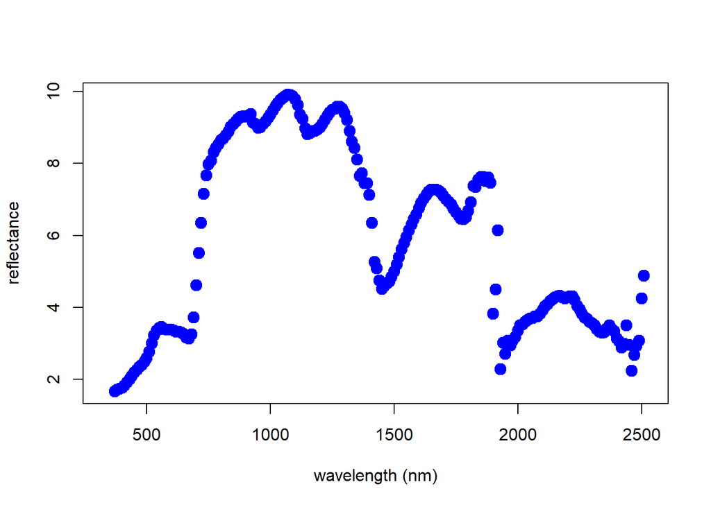

```r
plot(dat$wave, dat$s1, pch=19, cex=1.5, xlab= "wavelength (nm)", ylab="reflectance", col="blue")
```

Try adding some of the samples to the plot as additional lines; If you prefer ggplot to base R plotting, feel free to use that

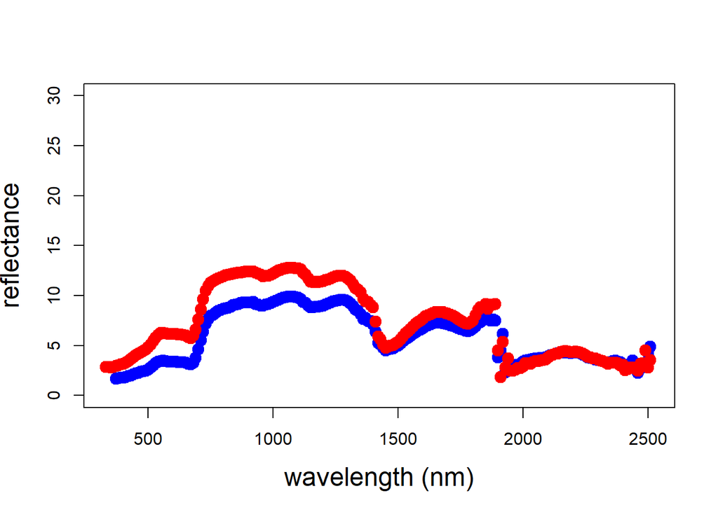

```r
##cex is the symbol size, cex.lab is the axis label size
plot(dat$wave, dat$s1, pch=19, cex=1.5,  col="blue", ylim=c(0,30),
xlab= "wavelength (nm)", ylab="reflectance",cex.lab=1.5)

##add a new row of point data onto an existing plot
points(dat$wave, dat$s2, pch=19, cex=1.5,  col="red")
```

Advanced: can you write a for loop to plot all of the samples on the same plot, where each line a different color? Hint: you can try terrain.colors(n) or heat.colors(n) to generate an object of color values to use, where n is the number of colors; You can also grab a column in a data frame or tribble by using its column number.

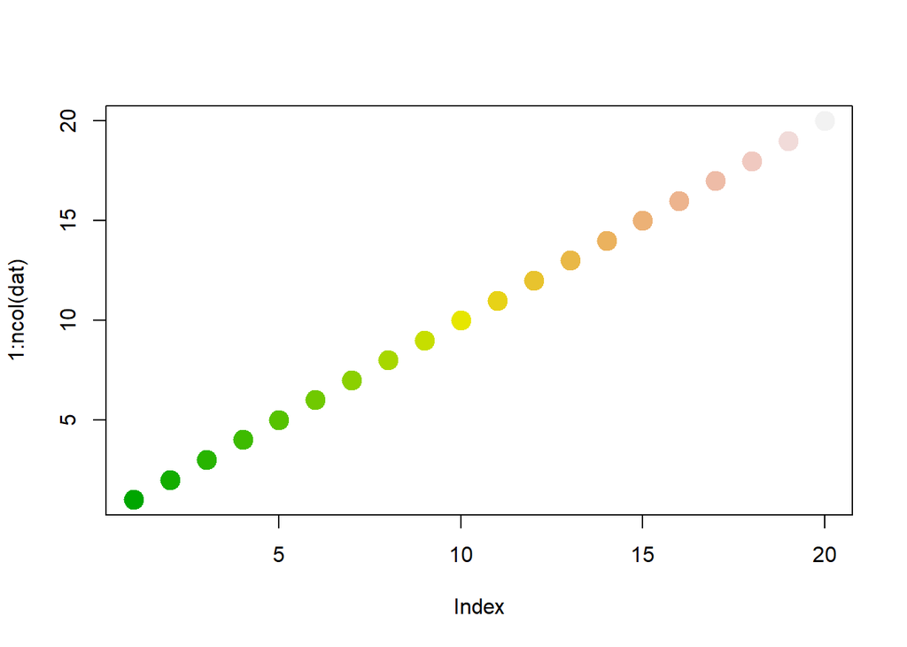

```r
##set up your color scheme, below we make a color ramp with as many columns as our data
color<-terrain.colors(ncol(dat))

##what colors are these?
plot(1:ncol(dat), pch=19, cex=2, col=color)
```

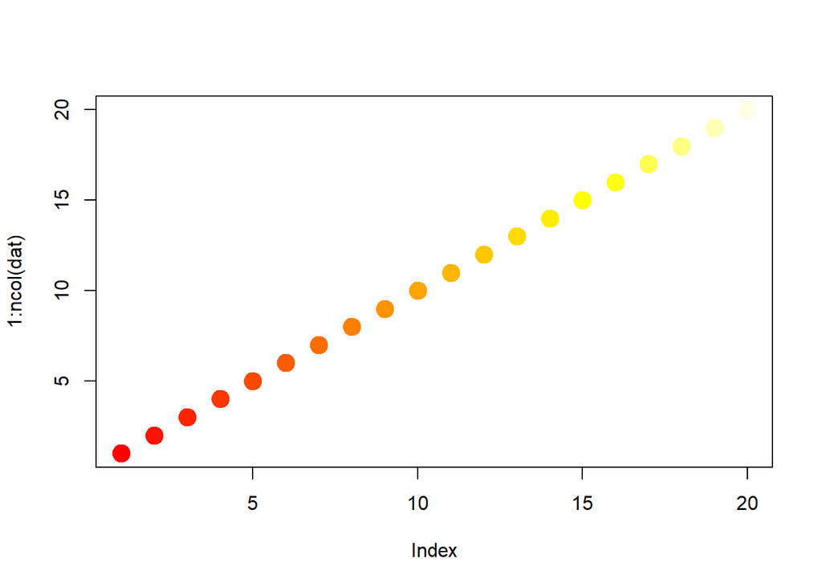

```r
##another color ramp
color<-heat.colors(ncol(dat))
##what colors are these?
plot(1:ncol(dat), pch=19, cex=2, col=color)
```

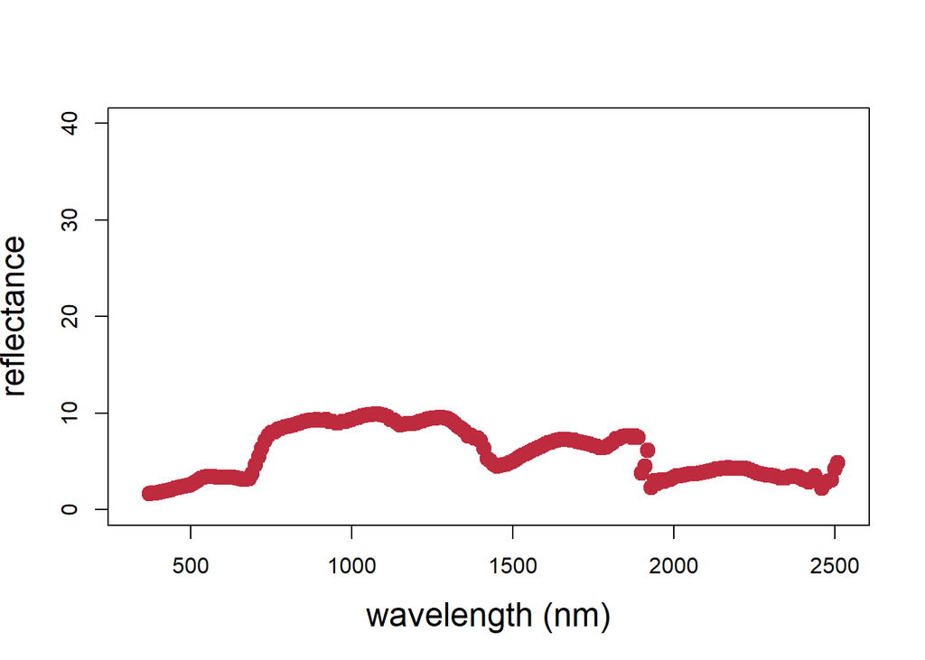

```r
##even more color ramps are in the package paletteer; Install first if you need to
##see https://r-charts.com/color-palettes/
library(paletteer)
color<-paletteer_c("ggthemes::Red-Green-Gold Diverging", ncol(dat))

##plot the first series in the first color
plot(dat$wave, dat$s1, pch=19, cex=1.5,  col=color[1], ylim=c(0,40),
xlab= "wavelength (nm)", ylab="reflectance",cex.lab=1.5)
```

```r
##use a for loop to add in other reflectance profiles from other columns, plotted in new colors
#for (i in 2:ncol(dat)) {
###fill in XX, YY and ?? with what you think should go there;
#points(XX, YY, pch=19, cex=1.5,  col=color[??])
#}
```

```r
color<-terrain.colors(ncol(dat))
dat<-data.frame(dat)

##output the plot to a file to save on your computer
##first line is the type of file, path to file, and file name
jpeg("results/myplot.jpeg")
plot(dat$wave, dat$s1, pch=19, cex=1.5, xlab= "wavelength (nm)", ylab="reflectance", col=color[1], ylim=c(0,40), cex.lab=1.5)

#for (i in 2:ncol(dat)) {
###fill in XX, YY and ?? with what you think should go there;
#points(XX, YY, pch=19, cex=1.5,  col=??)
#}

##the line below closes the plotting device and saves the file
dev.off()
```